title: “Prediction of student score” author: “Vishal Jain” date: “04.12.2021”

## Introduction

Presented here is the explanation of the chosen predicted model to predict the students’ score in assessments along with the R code to achieve that.

## Machine Learning Model Chosen: Support Vector Machines with Linear Kernel

Loading the required libraries

```r
library(dplyr)
library(tidyverse)
library(caret)
library(doSNOW)
library(xgboost)
```

```r
library(ggplot2)
```

Importing the studentInfo and studentAssessment csv files from the OULAD dataset

```r
#Reading the csv files
student.info <- read.csv("studentInfo.csv")
student.assessment <- read.csv("studentAssessment.csv")
```

The first order of business is merging the relevant variables from both files into a single dataframe.

```r
#Merging the studentInfo.csv and relevant variables from studentAssessment.csv to get more info about the students in the same dataframe
mergedInfo <- merge(x=student.assessment, y=student.info[,c("id_student","gender", "age_band", "studied_credits")], by="id_student")
```

The na.omit() functio can be used to get rid of any rows with missing data

```r
#Omitting any rows with NA values
mergedInfo <- na.omit(mergedInfo)


#Converting any character variables in the merged dataframe to factors
mergedInfo <-
  mergedInfo %>%
  mutate_if(is.character, as.factor)
```

It needs to be checked if there are any variables with little or no variability as this can affect the model

```r
nearZeroVar(mergedInfo, saveMetrics = TRUE)
```

```
##                 freqRatio percentUnique zeroVar   nzv
## id_student       1.045455  1.127566e+01   FALSE FALSE
## id_assessment    1.273973  9.078091e-02   FALSE FALSE
## date_submitted   1.172365  1.492090e-01   FALSE FALSE
## is_banked       57.368658  9.657544e-04   FALSE  TRUE
## score            1.547896  4.877059e-02   FALSE FALSE
## gender           1.343385  9.657544e-04   FALSE FALSE
## age_band         2.296618  1.448632e-03   FALSE FALSE
## studied_credits  2.885048  2.510961e-02   FALSE FALSE
```

We can see that the nzv field is TRUE for the ‘is_banked’ varibale, so we need to get rid of it

```r
#Resaving the dataframe as the same name but without the is-banked variable using select() function
mergedInfo <-
  mergedInfo %>%
  select(-is_banked)
```

```r
# Setting a seed to ensure the reproducibility
set.seed(2020)
```

Creating a trainIndex object that indexes 70% of the data, to follow the widely used 70-30 pattern for training and testing respectively:

```r
trainIndex <- createDataPartition(mergedInfo$score,
                                  p = .7,
                                  list = FALSE,
                                  times = 1)

score.train <- mergedInfo[trainIndex,]
score.test <- mergedInfo[-trainIndex,]
```

```r
train.control <- trainControl(number = 10,
                              repeats = 1,
                              method = "repeatedcv",
                              verboseIter = TRUE)
```

To make the training process faster, the doSNOW package has been used to train the model parallelly. Here, a cluster with 8 processes has been created, but this number depends on the number of cores/threads on the computer the code is being run on:

```r
cl <- makeCluster(8, type = "SOCK")
registerDoSNOW(cl)
```

Training the model using the previously set up control parameters and using the svmLinear model which has been selected by trial and error compared to a number of models including xgbTree, ranger etc.

```r
forestFit <- train(score ~ .,
                 data = score.train,
                 method = "svmLinear",
                 trControl = train.control,
                 verbose = TRUE)
#Clearing the cluster created to free up the memory
stopCluster(cl)

#Examining the model
forestFit
```

```
## Support Vector Machines with Linear Kernel
##
## 144967 samples
##      6 predictor
##
## No pre-processing
## Resampling: Cross-Validated (10 fold, repeated 1 times)
## Summary of sample sizes: 130470, 130471, 130470, 130470, 130470, 130471, ...
## Resampling results:
##
##   RMSE      Rsquared    MAE
##   19.23126  0.01532217  14.40299
##
## Tuning parameter 'C' was held constant at a value of 1
```

Not the model can be used to predict the scores of the students in the testing module to check the accuracy of the created module:

```r
preds <- predict(forestFit, score.test)

#Creating a new object for the testing data with predicted values included
score.test.augmented <-
  score.test %>%
  mutate(pred = predict(forestFit, score.test),
         obs = score)

#Transforming this new object into a data frame
defaultSummary(as.data.frame(score.test.augmented))
```

```
##        RMSE    Rsquared         MAE
## 19.10577461  0.01737013 14.32796812
```

A scatterplot can be drawn using the predictions against the actual scores in the the testing module.

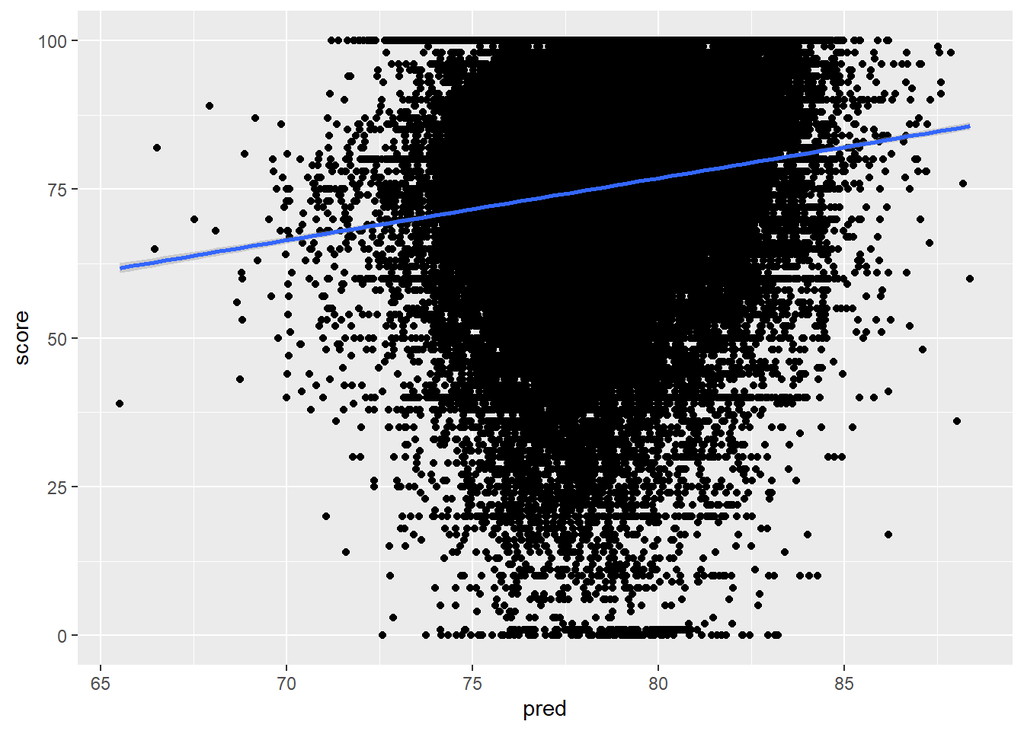

```r
ggplot(score.test.augmented, aes(x=pred,y=score)) +
  geom_point() +
  geom_smooth(method='lm', formula= y~x)
```